# Fair Play: Examining Pay Equity and Rise of International MLB Players

#### Perfomance Metrics

Because we built a dataset that already aggregated the groups of countries we are interested in because they have sufficient N’s to power our analyses, we can now build a model to learn about differences in Wins Above Average between international-born players in the 5 most represented countries and compare with WAA of players in the United States.

```r
top6_countries_data$WAA_batting <- as.numeric(top6_countries_data$WAA_batting)
intl_waa_batting <- top6_countries_data %>%
  filter(birthCountry != "USA") %>%
  select(playerID, WAA_batting, year_ID, birthCountry) %>%
  mutate(WAA_batting = case_when(
    WAA_batting == "NULL" ~ NA,
    TRUE ~ WAA_batting))

us_waa_batting <- top6_countries_data %>%
  filter(birthCountry == "USA") %>%
  select(playerID, WAA_batting, year_ID, birthCountry) %>%
  mutate(WAA_batting = case_when(
    WAA_batting == "NULL" ~ NA,
    TRUE ~ WAA_batting))

mean(intl_waa_batting$WAA_batting, na.rm= TRUE)
```

```
## [1] -0.03127914
```

```r
mean(us_waa_batting$WAA_batting, na.rm = TRUE)
```

```
## [1] 0.01599533
```

**Average WAA of international-born players:** -0.03

**Average WAA of US-born players:** 0.02

The average WAA of US-born players’ turns out to be more positive than international-born players. However, in order to determine exact group differences, we need to conduct ANOVA.

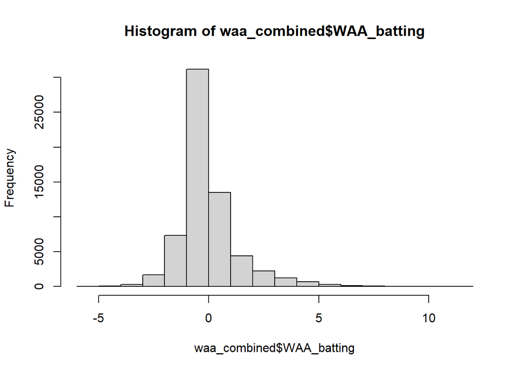

```r
waa_combined <- bind_rows(intl_waa_batting, us_waa_batting)
waa_combined <- na.omit(waa_combined)

hist(waa_combined$WAA_batting)
```

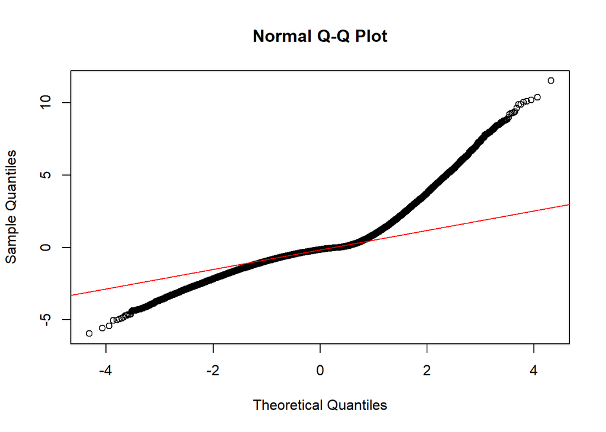

```r
qqnorm(waa_combined$WAA_batting)
qqline(waa_combined$WAA_batting, col = "red")
```

```r
# normality, skew and kurtosis tests for a large number of entries that exceed limits of Shapiro-Wilk test (n > 5000)

ad.test(waa_combined$WAA_batting)
```

```
##
##  Anderson-Darling normality test
##
## data:  waa_combined$WAA_batting
## A = 2535, p-value < 0.00000000000000022
```

```r
skewness(waa_combined$WAA_batting)
```

```
## [1] 1.663219
```

```r
kurtosis(waa_combined$WAA_batting)
```

```
## [1] 5.872779
```

```r
# cube root transformation
waa_combined$WAA_batting_cube <- sign(waa_combined$WAA_batting) * abs(waa_combined$WAA_batting)^(1/3)

ad.test(waa_combined$WAA_batting_cube)
```

```
##
##  Anderson-Darling normality test
##
## data:  waa_combined$WAA_batting_cube
## A = 2821.5, p-value < 0.00000000000000022
```

```r
skewness(waa_combined$WAA_batting_cube)
```

```
## [1] 0.5997844
```

```r
kurtosis(waa_combined$WAA_batting_cube)
```

```
## [1] -1.022927
```

```r
# ANOVA of debut ages of 6 countries with most players
anova_waa <- aov(WAA_batting_cube ~ birthCountry, data = waa_combined)
summary(anova_waa)
```

```
##                 Df Sum Sq Mean Sq F value Pr(>F)
## birthCountry     5     11  2.1158   2.775 0.0164 *
## Residuals    62995  48034  0.7625
## ---
## Signif. codes:  0 '***' 0.001 '**' 0.01 '*' 0.05 '.' 0.1 ' ' 1
```

```r
# Tukey to assess which pairs differ significantly
TukeyHSD(anova_waa)
```

```
##   Tukey multiple comparisons of means
##     95% family-wise confidence level
##
## Fit: aov(formula = WAA_batting_cube ~ birthCountry, data = waa_combined)
##
## $birthCountry
##                                        diff         lwr        upr     p adj
## Cuba-Canada                    -0.034546238 -0.16286166 0.09376918 0.9729798
## Dominican Republic-Canada      -0.087315946 -0.19638018 0.02174828 0.2015576
## Puerto Rico-Canada             -0.084835058 -0.20071442 0.03104430 0.2943861
## USA-Canada                     -0.053400215 -0.15202693 0.04522650 0.6363142
## Venezuela-Canada               -0.100784166 -0.21443982 0.01287148 0.1162448
## Dominican Republic-Cuba        -0.052769708 -0.14831861 0.04277919 0.6159253
## Puerto Rico-Cuba               -0.050288821 -0.15354875 0.05297111 0.7344667
## USA-Cuba                       -0.018853978 -0.10229148 0.06458352 0.9876461
## Venezuela-Cuba                 -0.066237929 -0.16699602 0.03452016 0.4186550
## Puerto Rico-Dominican Republic  0.002480887 -0.07557533 0.08053710 0.9999992
## USA-Dominican Republic          0.033915731 -0.01499210 0.08282356 0.3560437
## Venezuela-Dominican Republic   -0.013468220 -0.08818337 0.06124692 0.9956686
## USA-Puerto Rico                 0.031434843 -0.03121494 0.09408463 0.7087802
## Venezuela-Puerto Rico          -0.015949108 -0.10030178 0.06840356 0.9945794
## Venezuela-USA                  -0.047383951 -0.10581833 0.01105042 0.1895331
```

```r
anova_means_waa <- aggregate(WAA_batting ~ birthCountry, data = waa_combined, FUN = function(x) mean(x, na.rm = TRUE)) %>%
  arrange(desc(WAA_batting))

colnames(anova_means_waa)[2] <- "WAA"
colnames(anova_means_waa)[1] <- "Country"

kable(anova_means_waa,
      caption = "Average WAA of international players at debut, with USA")
```

| Country | WAA |
| --- | --- |
| Canada | 0.1328261 |
| USA | 0.0159953 |
| Cuba | -0.0262721 |
| Dominican Republic | -0.0332364 |
| Puerto Rico | -0.0362869 |
| Venezuela | -0.0828853 |

Countries with strong baseball infrastructures (like the Dominican Republic, Venezuela, or Cuba) may produce similarly high-quality players compared to domestic U.S. players, reducing the variance in WAA scores across countries. Additionally, it is reassuring that the recruitment model appears to select for talent, rather than specific nationalities, which could indicate bias.

Alternate concerns could be sample size or contextual factors that impact WAA. To address the former, we selected the countries with the most representation in the MLB, to improve power of analyses. As for the latter, it is impossible to predict all positive and negative factors that impact WAA over a given season, particularly with season-ending injuries, cultural differences, and sociopolitical events.

Finally, because we only analyzed offensive players, we are missing data about pitchers, some of whom have excellent WAA over the course of their long careers. Further analyses regarding pitching WAA will be completed at a future time.

## 5. Analysis 2: Pay Equity

Because we built a dataset that already aggregated the groups of countries we are interested in because they have sufficient N’s to power our analyses, we can now build a model to learn about differences in Wins Above Average between international-born players in the 5 most represented countries and compare with WAA of players in the United States.

```r
all_salary <- Salaries

colnames(all_salary)[1] <- "yearID"
colnames(intl_waa_batting)[3] <- "yearID"

intl_salary <- intl_waa_batting %>%
  left_join(all_salary, by = c("playerID", "yearID")) %>%
  filter(!is.na(salary))
nrow(intl_salary)
```

```
## [1] 3106
```

```r
length(unique(intl_salary$playerID))
```

```
## [1] 500
```

According to the read.me published by Sean Lahman in his most recent package, states that Salary data has not been updated since 2016. Additionally, data from seasons in which a player is injured, remains a free agent, or did not complete the entire season in the MLB (assigned to the minor leagues).

Therefore, the data that will be analyzed for the remainder of this project will only include players with complete salary data between the years of 1985 and 2016. Players who do not meet this criteria will be excluded from the analyses, bringing our N to 3106.

#### International Player Salary EDA

Important to note that 3106 represents the sum of all seasons in which international-born players completed a full season between 1985 and 2016 - NOT the number of unique playerIDs, of which there are 500.

```r
summary(intl_salary$salary)
```

```
##     Min.  1st Qu.   Median     Mean  3rd Qu.     Max.
##    60000   330500   775000  2809113  3333333 28000000
```

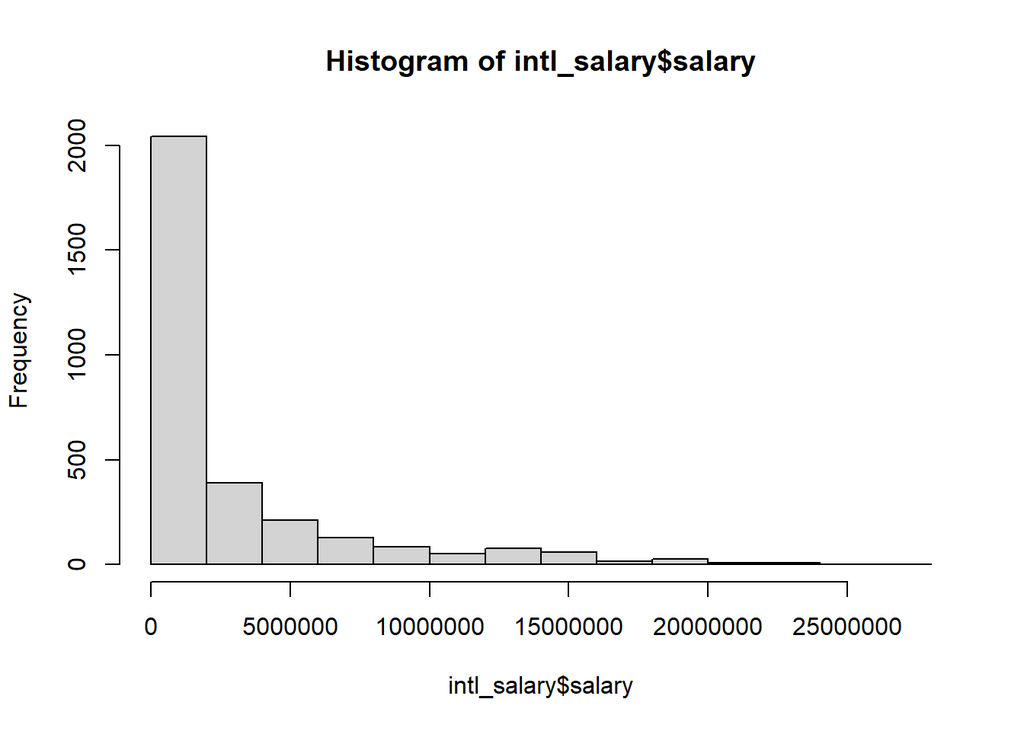

```r
# compare salary distribution for international players
hist(intl_salary$salary)
```

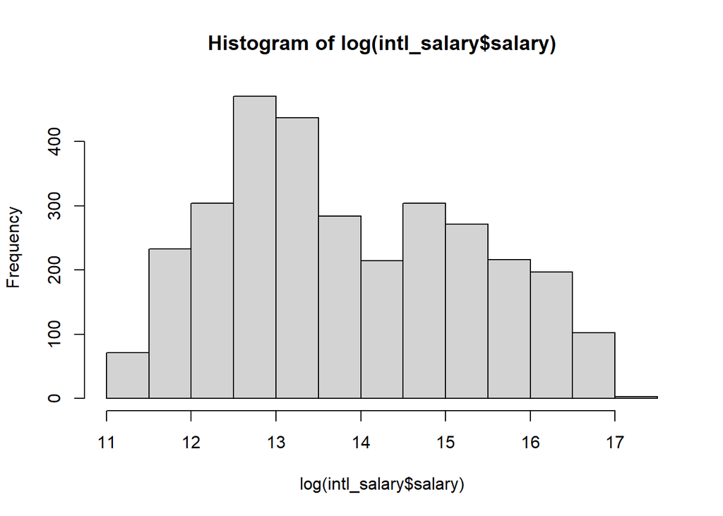

```r
# log transformation
hist(log(intl_salary$salary))
```

Clearly there is quite a range of salaries, to the point that most distributions of salary are heavily skewed to the right, which makes sense, given that the most outstanding players are few and far between. Players on the lower end might constitute a lack of playing time, short careers, and/or poor market value.

When log transformed, we get something closer to a bimodal distribution, as other methods of transformations were unsuccessful.

```r
cor_waa_salary <- cor(log(intl_salary$salary), intl_salary$WAA_batting, use = "complete.obs", method = "pearson")
print(cor_waa_salary)
```

```
## [1] 0.2624735
```

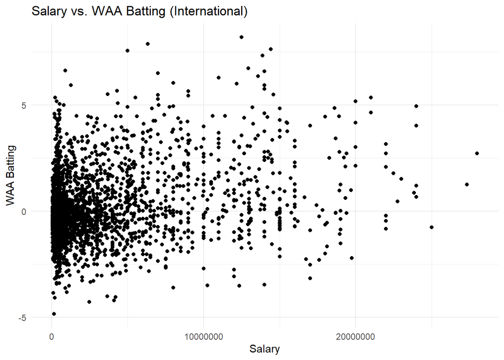

```r
ggplot(intl_salary, aes(x = salary, y = WAA_batting)) +
  geom_point() +
  labs(title = "Salary vs. WAA Batting (International)",
       x = "Salary",
       y = "WAA Batting") +
  theme_minimal()
```

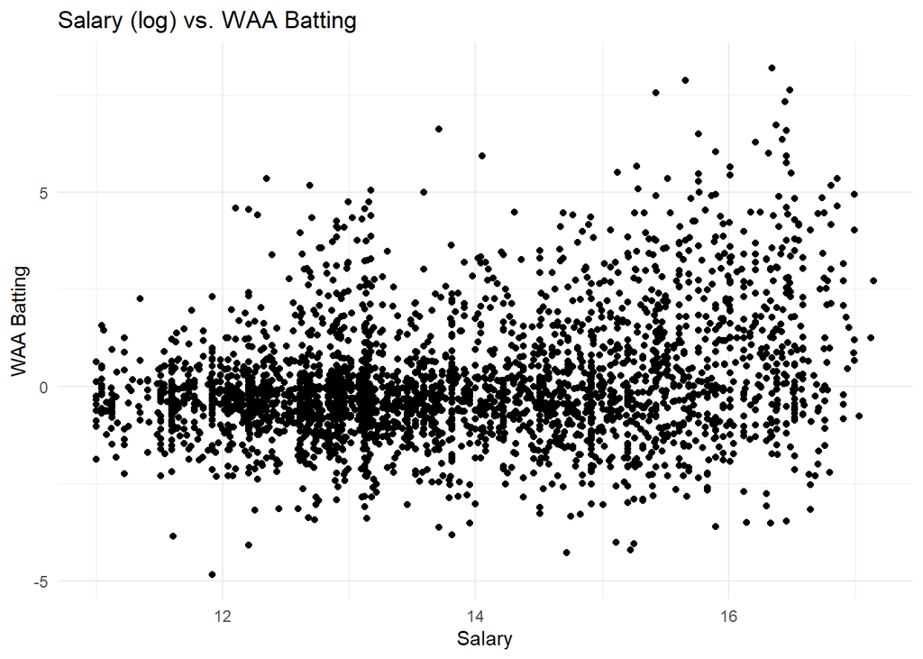

```r
ggplot(intl_salary, aes(x = log(salary), y = WAA_batting)) +
  geom_point() +
  labs(title = "Salary (log) vs. WAA Batting",
       x = "Salary",
       y = "WAA Batting") +
  theme_minimal()
```

```r
lm_waa_salary <- lm(salary ~ WAA_batting,
                      data = intl_salary)
summary(lm_waa_salary)
```

```
##
## Call:
## lm(formula = salary ~ WAA_batting, data = intl_salary)
##
## Residuals:
##      Min       1Q   Median       3Q      Max
## -7036209 -2275362 -1494455   642180 23599853
##
## Coefficients:
##             Estimate Std. Error t value            Pr(>|t|)
## (Intercept)  2758316      73567   37.49 <0.0000000000000002 ***
## WAA_batting   782159      47305   16.53 <0.0000000000000002 ***
## ---
## Signif. codes:  0 '***' 0.001 '**' 0.01 '*' 0.05 '.' 0.1 ' ' 1
##
## Residual standard error: 4096000 on 3104 degrees of freedom
## Multiple R-squared:  0.08094,    Adjusted R-squared:  0.08065
## F-statistic: 273.4 on 1 and 3104 DF,  p-value: < 0.00000000000000022
```

When looking at international players as a monolith, we can see that there is a very weak positive correlation between WAA and salary. Even after a log transformation and assessment with a linear model, there does not appear to be a strong (if any) relationship between WAA and salary.

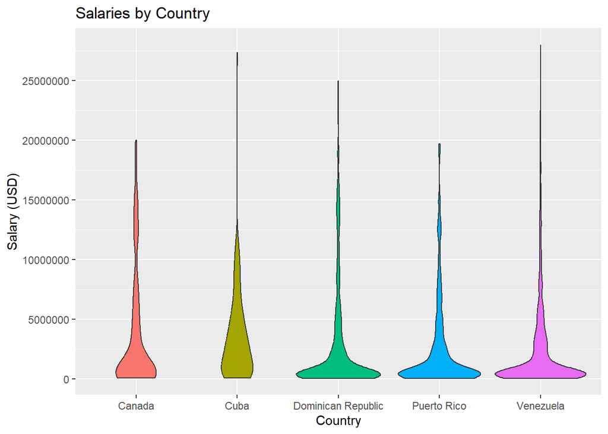

```r
qplot(x = birthCountry, y = salary,
      data= intl_salary,
      geom = "violin", fill = birthCountry) +
  labs(title = "Salaries by Country",
       x = "Country", y = "Salary (USD)") +
  theme(legend.position = "none") +
  scale_y_continuous(breaks = seq(0, max(intl_salary$salary), by = 5000000))
```

Again, visualization by country also shows that there are very few superstars and the distribution of salaries reflects this trend when international players are combined together. In particular, it is clear that Cuba appears to have more heterogeneity in their pay; whereas, the latter three on the plot show that there is some evidence for superstars skewing the salary distribution heavily.

With that said, let’s take a quick look at the US players and then compare with international-born players.

#### Domestic Player Salary EDA

```r
all_salary <- Salaries

colnames(all_salary)[1] <- "yearID"
colnames(us_waa_batting)[3] <- "yearID"

us_salary <- us_waa_batting %>%
  left_join(all_salary, by = c("playerID", "yearID")) %>%
  filter(!is.na(salary))
nrow(us_salary)
```

```
## [1] 11465
```

```r
length(unique(us_salary$playerID))
```

```
## [1] 1847
```

```r
# explore the range of values
summary(us_salary$salary)
```

```
##     Min.  1st Qu.   Median     Mean  3rd Qu.     Max.
##        0   300000   600000  2096058  2373439 33000000
```

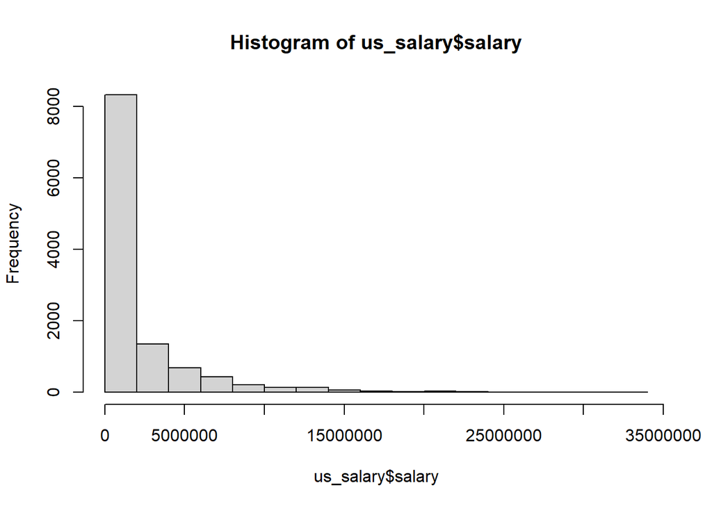

```r
# compare salary distribution for international players
hist(us_salary$salary)
```

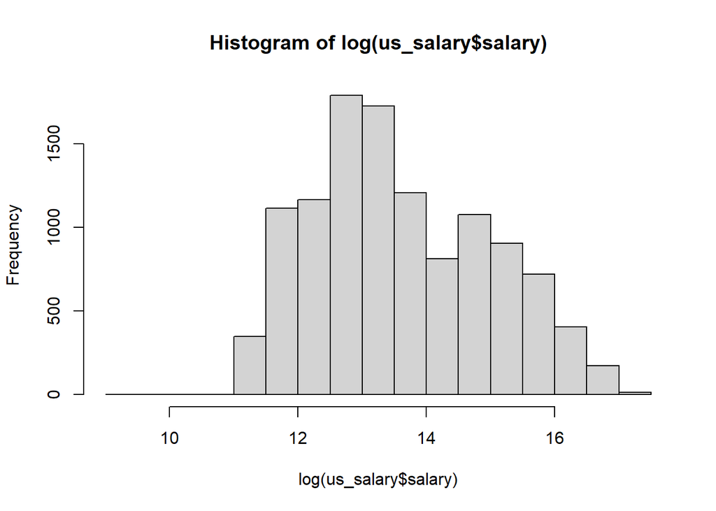

```r
# log transformation
hist(log(us_salary$salary))
```

Clearly there is quite a range of salaries, to the point that most distributions of salary are heavily skewed to the right, which makes sense, given that the most outstanding players are few and far between. Players on the lower end might constitute a lack of playing time, short careers, and/or poor market value.

When log transformed, we get something closer to a bimodal distribution, as other methods of transformations were unsuccessful.

```r
cor_waa_salary_dom <- cor(us_salary$salary, us_salary$WAA_batting, use = "complete.obs", method = "pearson")
print(cor_waa_salary_dom)
```

```
## [1] 0.1627957
```

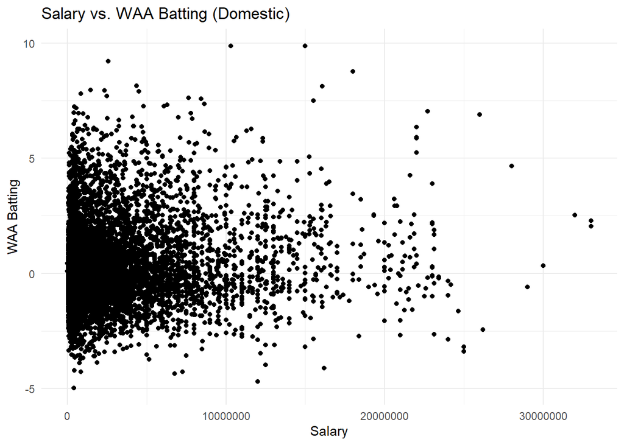

```r
ggplot(us_salary, aes(x = salary, y = WAA_batting)) +
  geom_point() +
  labs(title = "Salary vs. WAA Batting (Domestic)",
       x = "Salary",
       y = "WAA Batting") +
  theme_minimal()
```

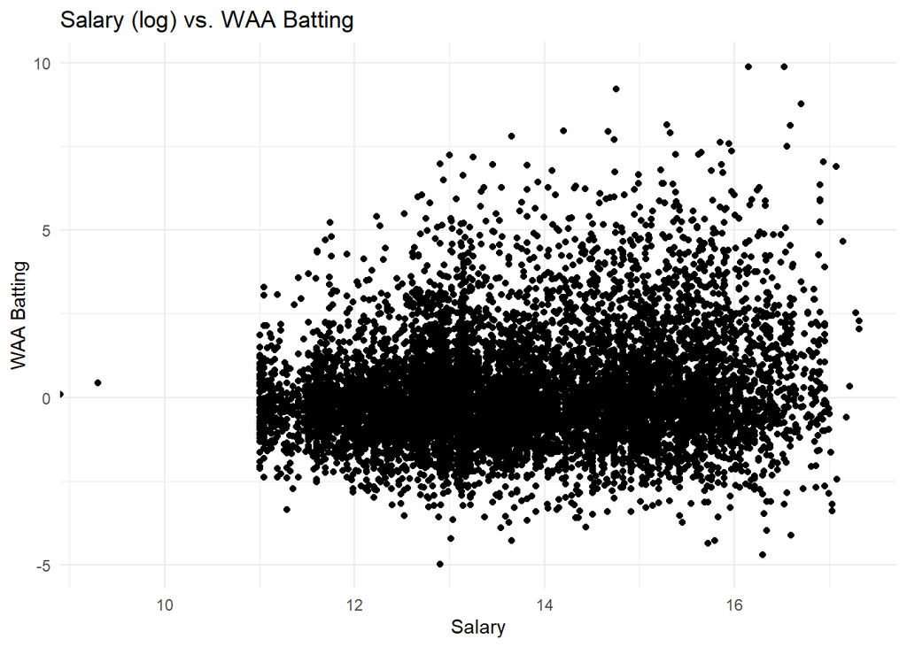

```r
ggplot(us_salary, aes(x = log(salary), y = WAA_batting)) +
  geom_point() +
  labs(title = "Salary (log) vs. WAA Batting",
       x = "Salary",
       y = "WAA Batting") +
  theme_minimal()
```

```r
lm_waa_salary_dom <- lm(salary ~ WAA_batting,
                      data = us_salary)
summary(lm_waa_salary_dom)
```

```
##
## Call:
## lm(formula = salary ~ WAA_batting, data = us_salary)
##
## Residuals:
##      Min       1Q   Median       3Q      Max
## -4354137 -1730167 -1278426   267261 30162030
##
## Coefficients:
##             Estimate Std. Error t value            Pr(>|t|)
## (Intercept)  2069636      31687   65.31 <0.0000000000000002 ***
## WAA_batting   376635      21320   17.66 <0.0000000000000002 ***
## ---
## Signif. codes:  0 '***' 0.001 '**' 0.01 '*' 0.05 '.' 0.1 ' ' 1
##
## Residual standard error: 3389000 on 11463 degrees of freedom
## Multiple R-squared:  0.0265, Adjusted R-squared:  0.02642
## F-statistic: 312.1 on 1 and 11463 DF,  p-value: < 0.00000000000000022
```

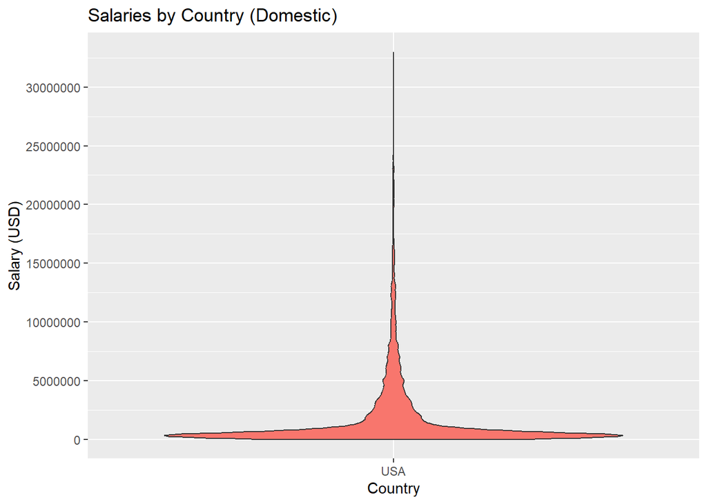

```r
qplot(x = birthCountry, y = salary,
      data= us_salary,
      geom = "violin", fill = birthCountry) +
  labs(title = "Salaries by Country (Domestic)",
       x = "Country", y = "Salary (USD)") +
  theme(legend.position = "none") +
  scale_y_continuous(breaks = seq(0, max(us_salary$salary), by = 5000000))
```

When looking at domestic players as a monolith, we can see that there is a very weak positive correlation between WAA and salary. Even after a log transformation and assessment with a linear model, there does not appear to be a strong (if any) relationship between WAA and salary among domestic players, so we see a similar trend to international players, despite the larger sample size.

When shown as a violin plot, we see a very large range amongst players, but it is important to note that there are nearly 4x the number of US players, compared to international born players, creating more opportunities in pay disparity.

#### Performance Metrics and Salary over Time

Lastly, I want to assess whether there are significant differences in pay with regards to WAA, controlling for time spent in the league, between international and domestic players. We will use ANCOVA to create a model to assess the relationship between these factors and whether there is indeed a pay discrepancy between domestic and international players

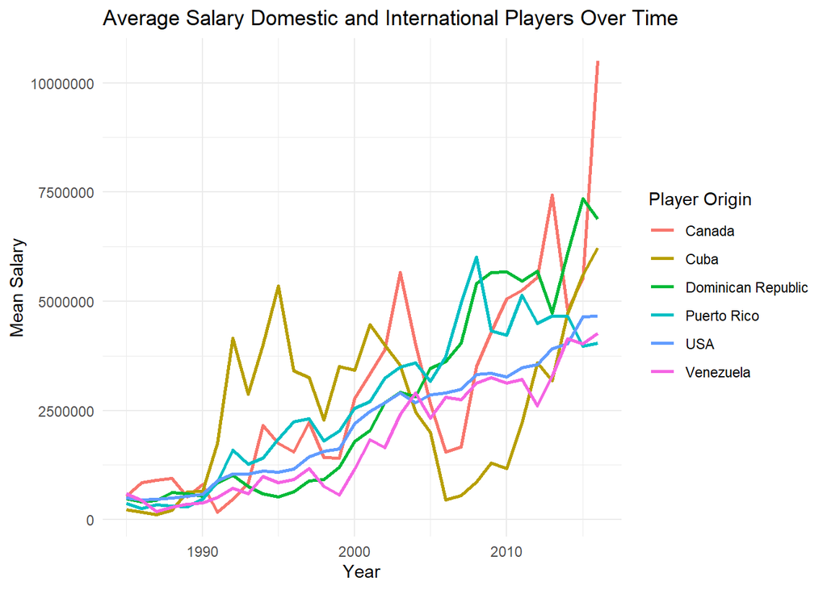

```r
# combine intl and us salaries
salary_comb <- bind_rows(intl_salary, us_salary)

# average salary by country
mean_salary_by_origin <- aggregate(
  salary ~ yearID + birthCountry,
  data = salary_comb[!is.na(all_salary$salary), ],
  FUN = mean
)

# trends over the years
salary_trends <- aggregate(
  salary ~ yearID + birthCountry,
  data = mean_salary_by_origin,
  FUN = function(x) mean(x, na.rm = TRUE)
)

# plotting changing trends in pay
ggplot(salary_trends, aes(x = yearID, y = salary, color = birthCountry)) +
  geom_line(linewidth = 1) +
  labs(
    title = "Average Salary Domestic and International Players Over Time",
    x = "Year",
    y = "Mean Salary",
    color = "Player Origin"
  ) +
  theme_minimal()
```

Using this line graph, we can assess the change in average pay per player from each country of interest over a period of time. Something interesting to note is the large spike in the Canadian data, which corresponds to significant contract signings, such as Freddie Freeman, Justin Morneau and Joey Votto, that propelled the average salary for Canadian-born players extremely high, combined with a shrinking number of Canadian players.

```r
# prepare dataset for ancova analysis
ancova_data <- salary_comb %>%
  filter(!is.na(salary), !is.na(birthCountry), !is.na(yearID), !is.na(WAA_batting))

ancova_data$birthCountry <- as.factor(ancova_data$birthCountry)

ancova_data <- ancova_data %>%
  filter(birthCountry %in% c("USA", "Dominican Republic", "Venezuela", "Japan", "Cuba", "Canada"))

# run anvcova and return results
ancova_model <- aov(salary ~ birthCountry + yearID + WAA_batting + birthCountry:yearID, data = ancova_data)
summary(ancova_model)
```

```
##                        Df             Sum Sq           Mean Sq F value
## birthCountry            4   1489737350671074   372434337667769   34.52
## yearID                  1  24449616722622180 24449616722622180 2266.46
## WAA_batting             1   6487281242068969  6487281242068969  601.37
## birthCountry:yearID     4    785803297791809   196450824447952   18.21
## Residuals           13824 149127473670361568    10787577667127
##                                   Pr(>F)
## birthCountry        < 0.0000000000000002 ***
## yearID              < 0.0000000000000002 ***
## WAA_batting         < 0.0000000000000002 ***
## birthCountry:yearID  0.00000000000000623 ***
## Residuals
## ---
## Signif. codes:  0 '***' 0.001 '**' 0.01 '*' 0.05 '.' 0.1 ' ' 1
```

```r
# post-hoc analyses to look at pairwise relationships
pairwise <- emmeans(ancova_model, pairwise ~ birthCountry)
```

```
## NOTE: Results may be misleading due to involvement in interactions
```

```r
summary(pairwise)
```

```
## $emmeans
##  birthCountry        emmean     SE    df lower.CL upper.CL
##  Canada             2383759 307000 13824  1781600  2985918
##  Cuba               2651008 297000 13824  2068548  3233468
##  Dominican Republic 2643197  94200 13824  2458556  2827838
##  USA                2184128  30700 13824  2123857  2244400
##  Venezuela          1857129 134000 13824  1595437  2118822
##
## Confidence level used: 0.95
##
## $contrasts
##  contrast                       estimate     SE    df t.ratio p.value
##  Canada - Cuba                   -267249 427000 13824  -0.625  0.9710
##  Canada - Dominican Republic     -259438 321000 13824  -0.807  0.9285
##  Canada - USA                     199631 309000 13824   0.647  0.9673
##  Canada - Venezuela               526630 335000 13824   1.572  0.5156
##  Cuba - Dominican Republic          7811 312000 13824   0.025  1.0000
##  Cuba - USA                       466880 299000 13824   1.563  0.5214
##  Cuba - Venezuela                 793879 326000 13824   2.437  0.1057
##  Dominican Republic - USA         459069  99100 13824   4.633  <.0001
##  Dominican Republic - Venezuela   786068 163000 13824   4.812  <.0001
##  USA - Venezuela                  326999 137000 13824   2.387  0.1189
##
## P value adjustment: tukey method for comparing a family of 5 estimates
```

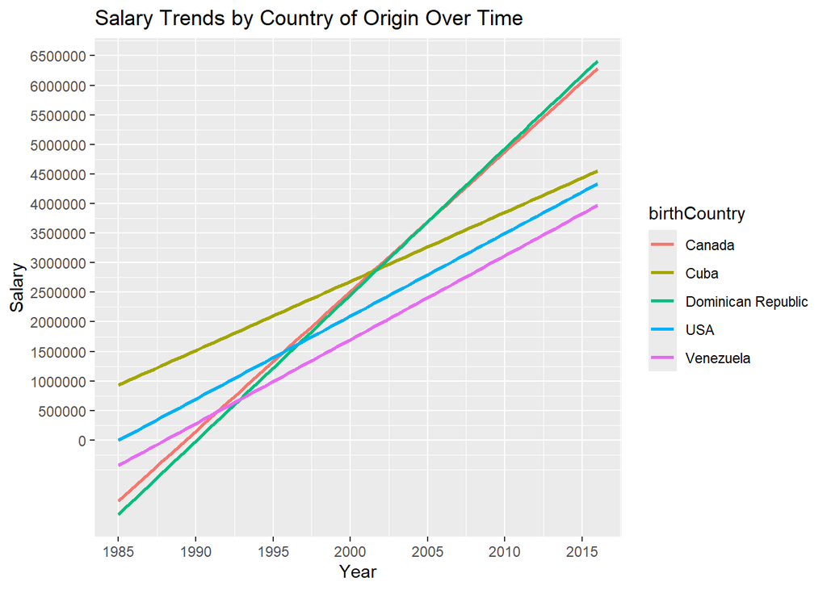

```r
# plot interaction effects
ggplot(ancova_data, aes(x = yearID, y = salary, color = birthCountry)) +
    geom_smooth(method = "lm", se = FALSE) +
    labs(title = "Salary Trends by Country of Origin Over Time",
         x = "Year",
         y = "Salary") +
  scale_x_continuous(breaks = seq(min(ancova_data$yearID), max(ancova_data$yearID)+4, by = 5)) +
  scale_y_continuous(breaks = seq(min(ancova_data$salary), max(ancova_data$salary), by = 500000))
```

**Main Effects:**

The p-value for birthCountry is extremely small, indicating a statistically significant difference in mean salaries across countries of origin after controlling for other variables. The F-statistic (34.52) suggests a strong effect of country of origin on salary.

yearID also shows a highly significant effect, meaning that salaries have significantly changed over the years. The very high F-statistic (2266.46) highlights the impact of time on salary trends.

WAA_batting is significant with an F-statistic of 601.37, showing that better performance correlates with higher salaries.

**Interaction Effects:**

The interaction term birthCountry:yearID is significant, meaning the relationship between salary and year differs across countries. This implies that salary growth trends over time are not uniform across player origins.

## 6. Conclusions and Future Directions

Based on the results summarized through this project, there appear to be differences between domestic and international players, perhaps not in the way originally imagined. Anecdotal evidence and logical assumptions make it easy to overlook contextual factors that drive significant effects once you burrow into the numbers.

We’ve witnessed how the proportion of international players has expanded in the MLB, we’ve looked at performance metrics amongst different groups, as well as how those performance metrics predict the rate of compensation and whether country of origin significantly impacts this relationship.

There is still work to be done to improve the quality of life for internationally-born players, such as greater access to social support, early childhood education, financing for housing/transportation/family planning - just to name a few. Furthermore, access to U.S. college education provides an important pipeline for personal and professional development; increasing those opportunities for international players could lead to even greater market value, while also gaining valuable years of academic and athletic resources.

## 7. References

Baseball Reference. (2024). Data. Retrieved December 7, 2024, from https://www.baseball-reference.com/data/

Baseball Reference. (2024). Wins Above Average (WAA) – Batting statistics. Retrieved December 7, 2024, from https://www.baseball-reference.com/about/waa_batting.shtml

Chavez, L. (2018). The influence of international talent on MLB salaries. Baseball Research Journal, 45(2), 12–28. https://doi.org/10.1177/0034355218764759

Hernandez, B. (2020). Understanding the global expansion of Major League Baseball. Journal of Sports Economics, 21(4), 340–355. https://doi.org/10.1177/1527002520903835

Lahman, L. (2024). Lahman Baseball Database. Retrieved December 7, 2024, from https://cran.r-project.org/web/packages/Lahman/Lahman.pdf

Major League Baseball. (2024). Major League Baseball statistics. Retrieved from https://www.mlb.com/stats

Tingley, D. (2019). R for data science (2nd ed.). O’Reilly Media. https://r4ds.had.co.nz

Wickham, H. (2016). ggplot2: Elegant graphics for data analysis. Springer. https://ggplot2.tidyverse.org